# Brincando com a Exponencial

Pedro Tótolo

27/04/2021

**Obs:** Para que os resultados obtidos fossem análogos e comparáveis a métodos verossimilhancistas, em todos os modelos foi utilizada a distribuição a priori imprópria $p(\lambda) \propto I_{[0,\infty)}(\lambda)$.

### Dados sem censura

Imagine que temos uma amostra $\{T_i\}_{i=1}^n$ de tamanho $n=10$ com $T_i \sim Exp(\lambda)$. Nessa simulação $\lambda$ é igual a $\frac{1}{24}$, que é representado pela reta pontilhada.

```
##  [1] 136  20  12   5  32  67  17   5   6  60
```

Estimar $\lambda$ é muito fácil:

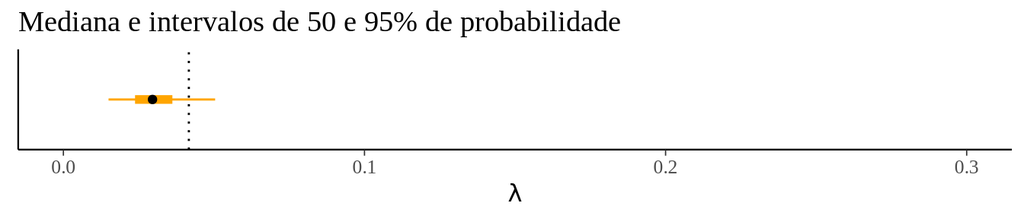

Se ocorre censura, no entanto, temos uma situação mais complexa em mãos.

### Dados com censura

Imagine que os dados anteriores fossem censurados à direita em um momento $U=24$. Isso pode representar por exemplo a situação em que o estudo termina ou é interrompido por questões éticas como no exemplo dos ratinhos.

```
##        [,1] [,2] [,3] [,4] [,5] [,6] [,7] [,8] [,9] [,10]
## t        24   20   12    5   24   24   17    5    6    24
## evento    0    1    1    1    0    0    1    1    1     0
```

Uma primeira ideia poderia ser descartar os dados censurados. Isso simplifica o problema, o que é frequentemente bom. É importante no entanto perceber que descartando os dados censurados, a distribuição amostral passa a ter suporte finito e ignorar isso é desastroso. O próximo gráfico exemplifica a gravidade desse erro.

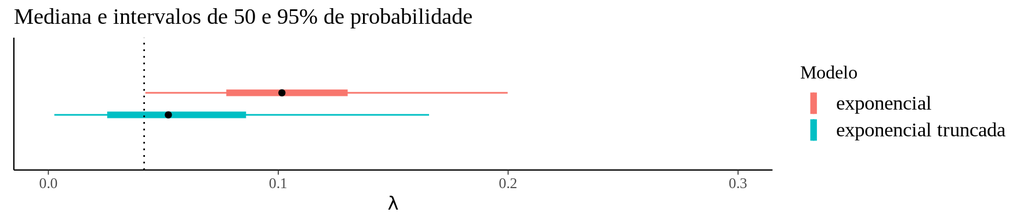

Apesar de correto, existem dois fatos que tornam o modelo truncado pouco eficiente:

1. Como parte da amostra é descartada, estamos utilizando menos informação para inferência;
2. É difícil distinguir entre diferentes possíveis $\lambda$ para a exponencial truncada quando $\lambda$ é provavelmente pequeno.

O item 1 é óbvio mas o 2 talvez nem tanto. A maneira mais natural de se notar este fato é comparar a informação de Fisher da verossimilhança exponencial com a da verossimilhança exponencial truncada:

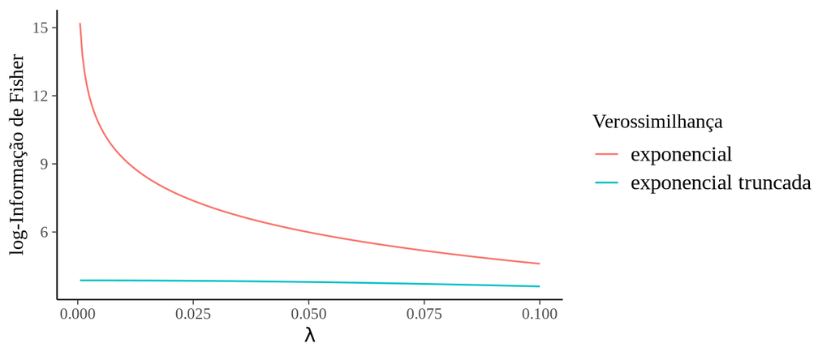

Lembrando que a informação de Fisher pode ser interpretada como a curvatura esperada da log-verossimilhança, a dramática diferença nessa função para os dois modelos evidencia a necessidade de uma amostra muito maior sob o modelo truncado para que $\lambda$ seja estimado com a mesma confiança que no modelo com suporte em $[0,\infty)$.

### Próximos passos

Em algumas semanas estudaremos uma maneira mais eficiente de lidar com dados censurados. O próximo gráfico compara esta abordagem com as apresentadas anteriormente.

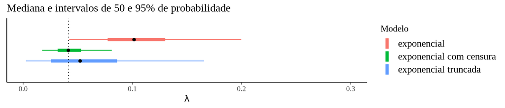

Para exacerbar a diferença entre esses modelos, foi repetida a simulação com $n=1000$.

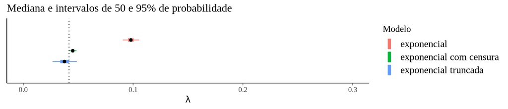